# Experiments with ARPEGE-Climat model

In this vignette, we attempt to provide a quick demo how to generate results of Section 5 of [@volodina2018diagnostic].

#### Preliminaries

We start with loading the necessary packages, functions and compilation of `Stan` files that are necessary to construct a stationary and nonstationary GP emulators.

```r
setwd('..')
source('BuildEmulator/BuildEmulator.R')
source('BuildEmulator/BuildEmulatorNSt.R')
```

In this Section, we consider the average potential temperature generated by the SCM by varying nine input parameters of interest, all associated with the parameterization of convection.

Firstly, we identified the physically plausible ranges of the input model parameters with the HIGH-TUNE team and standardazied them to the range $[-1, 1]$, which is the usual practice in constructing emulators for computer experiments.

```r
load('../Demonstrations/cnrmMasterWave1_US.RData')
scaledParams <- cnrmMasterWave1_US
cands <- c(names(scaledParams)[-c(1, 11:14)])

load('../Demonstrations/cnrmWave1.RData')
FullData <- tData
m = mean(FullData$SCMdata)
s.d = sd(FullData$SCMdata)
FullData$SCMdata <- (FullData$SCMdata - m)/s.d
```

We produce the plots of the average potential temperature against each input. We observe that the average potential temperature varies most with the input `ALFX`, i.e. the variability in the response of the average potential temperature increases as `ALFX` increases.

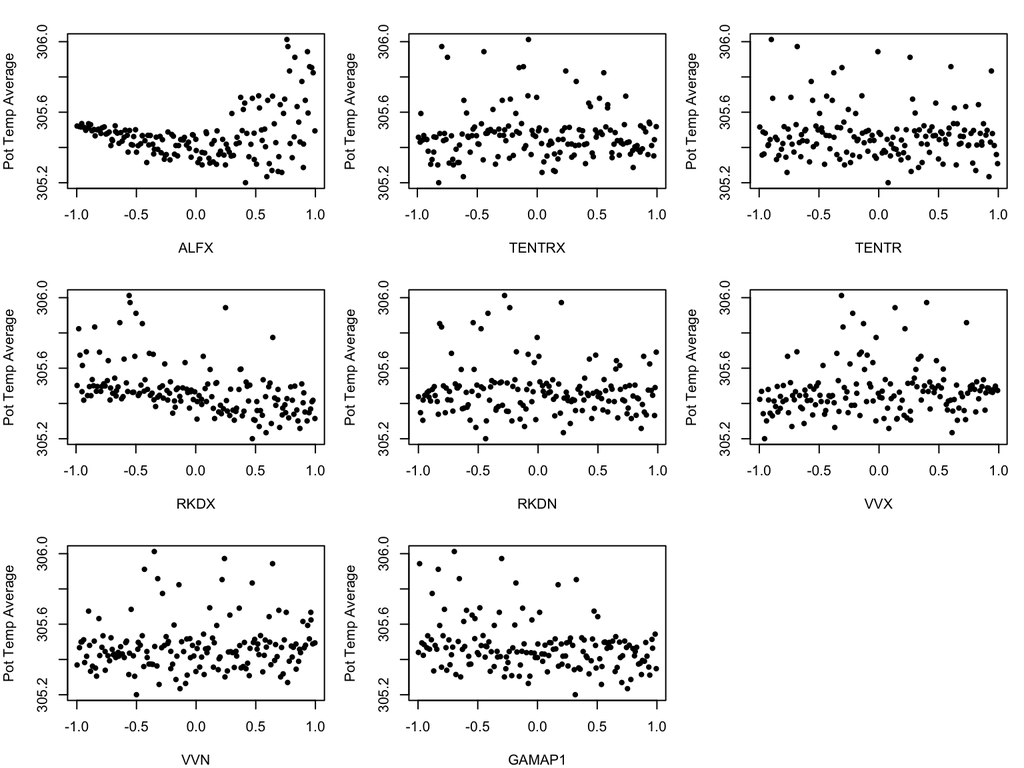

```r
par(mfrow = c(3, 3), mar = c(4, 4, 2, 1))
for(i in 1:(length(cands)-1)) {
  plot(FullData[, cands[i]], FullData[, "SCMdata"]*s.d+m, pch = 20, xlab = cands[i],
       ylab = 'Pot Temp Average')
}
```

We choose first 120 points to train our emulators and the remaining 40 points are used for validation purpose.

```r
tData = FullData[1:120, ]
tData.valid =  FullData[121:160,]
head(tData)
```

```
##          ALFX      TENTRX      TENTR       RKDX        RKDN         VVX
## 1  0.30001137 -0.97069174 -0.1928708  0.1205414 -0.64224285 -0.12140496
## 2 -0.89968906  0.01740040 -0.4774003  0.8861751 -0.69197355  0.09457564
## 3  0.74270569 -0.22388121  0.2830404 -0.9669966  0.48148095 -0.09919265
## 4  0.89906039  0.80108132  0.3328454  0.6318558  0.26913381 -0.62617477
## 5 -0.02982919 -0.03334369 -0.6465328 -0.6623497  0.56450136  0.84361558
## 6  0.47187173  0.51990493 -0.8869878 -0.3549518 -0.08295647 -0.16335517
##          VVN     GAMAP1   REFLCAPE      FNEBC       RQLCR    RAUTEFR
## 1  0.1728073 -0.8185718 -0.9155161 -0.4142488 -0.33462728 -0.3286926
## 2  0.7393054 -0.7416000  0.6464448 -0.6124089 -0.09271892 -0.1126076
## 3 -0.9016202  0.4738241  0.3092267  0.1593144 -0.79717671  0.1620079
## 4 -0.1692253  0.7816716  0.7815247  0.6625219  0.52382147 -0.2664361
## 5 -0.6328080 -0.4242097  0.8602944 -0.3951108  0.27591541 -0.4557898
## 6  0.6934439 -0.5941942  0.7033497  0.5755255 -0.41494045  0.5229699
##         TFLV     SCMdata      Noise
## 1 -0.9570590  0.87189274  0.4283970
## 2  0.5272175  0.28860029 -0.2065980
## 3 -0.2795316  1.45344077  0.0737952
## 4 -0.6347346 -1.31648970 -0.2563696
## 5 -0.9080671  0.01276293 -0.2772407
## 6 -0.7695477  1.48658486  0.4618558
```

#### Construct a stationary GP emulator

```r
myem.lm.cnrm = EMULATE.lm(Response="SCMdata", tData=tData, tcands=cands,
                            tcanfacs=NULL,TryFouriers=TRUE,maxOrder=4,maxdf = 30)
```

```
## [1] "Max Fourier reduction is 0.129762519041134 using sin(pi*1*ALFX) and cos(pi*1*ALFX)"
## [1] "Max reduction is 0.131587186322193 using RKDX"
## [1] "Max Fourier reduction is 0.130540483988215 using sin(pi*1*ALFX) and cos(pi*1*ALFX)"
## [1] "Max reduction is with the Fourier term"
## [1] "Max Fourier reduction is 0.0275175409953079 using sin(pi*1*GAMAP1) and cos(pi*1*GAMAP1)"
## [1] "Max reduction is 0.0823769141034068 using ALFX"
## [1] "Max Fourier reduction is 0.033843370542707 using sin(pi*1*GAMAP1) and cos(pi*1*GAMAP1)"
## [1] "Max reduction is 0.110894289176038 using GAMAP1"
## [1] "Max Fourier reduction is 0.0134230959925967 using sin(pi*3*RKDX) and cos(pi*3*RKDX)"
## [1] "Max reduction is with the Fourier term"
## [1] "Max Fourier reduction is 0.00759297484632404 using sin(pi*4*REFLCAPE) and cos(pi*4*REFLCAPE)"
## [1] "Max reduction is 0.0089729713778553 using TENTR"
## [1] "Max Fourier reduction is 0.00878943708447977 using sin(pi*4*REFLCAPE) and cos(pi*4*REFLCAPE)"
## [1] "Max reduction is 0.00955745468805064 using VVX"
## [1] "Max Fourier reduction is 0.0134767671634808 using sin(pi*1*VVX) and cos(pi*1*VVX)"
## [1] "Max reduction is with the Fourier term"
## [1] "Max Fourier reduction is 0.0119548821389903 using sin(pi*3*VVX) and cos(pi*3*VVX)"
## [1] "Max reduction is with the Fourier term"
## [1] "Max Fourier reduction is 0.0113974833252399 using sin(pi*2*ALFX) and cos(pi*2*ALFX)"
## [1] "Max reduction is 0.0135166486137984 using ALFX"
## [1] "Max Fourier reduction is 0.00667058665080539 using sin(pi*4*RKDN) and cos(pi*4*RKDN)"
## [1] "Max reduction is 0.0141810496772302 using Three Way Interactions with ALFX"
## [1] "Max Fourier reduction is 0.0085430328078841 using sin(pi*3*TENTR) and cos(pi*3*TENTR)"
## [1] "Max reduction is 0.00889039513537943 using VVN"
## [1] "Max Fourier reduction is 0.0176313937993144 using sin(pi*4*TENTR) and cos(pi*4*TENTR)"
## [1] "Max reduction is with the Fourier term"
## [1] "Max Fourier reduction is 0.013066189622249 using sin(pi*3*TENTR) and cos(pi*3*TENTR)"
## [1] "Max reduction is with the Fourier term"
## [1] "Max Fourier reduction is 0.0104744072477873 using sin(pi*4*REFLCAPE) and cos(pi*4*REFLCAPE)"
## [1] "Max reduction is with the Fourier term"
## [1] "Max Fourier reduction is 0.00721029110549914 using sin(pi*3*RKDN) and cos(pi*3*RKDN)"
## [1] "Max reduction is with the Fourier term"
## [1] "Max Fourier reduction is 0.00948635695006872 using sin(pi*3*TENTRX) and cos(pi*3*TENTRX)"
## [1] "Max reduction is with the Fourier term"
## [1] "Max Fourier reduction is 0.00874860337879507 using sin(pi*4*TENTRX) and cos(pi*4*TENTRX)"
## [1] "Max reduction is with the Fourier term"
## [1] "Max Fourier reduction is 0.00778556606335074 using sin(pi*2*TENTRX) and cos(pi*2*TENTRX)"
## [1] "Max reduction is 0.00940492642753715 using RKDN"
## [1] "No further terms permitted with the given degrees of freedom"
##
```

[output cut: 294 more lines]

```
## I(cos(pi * VVX * 1))       0.09439    0.04972   1.898 0.060885 .
## I(sin(pi * REFLCAPE * 4))  0.02897    0.05478   0.529 0.598271
## I(sin(pi * TENTRX * 4))   -0.06254    0.05276  -1.185 0.239018
## I(cos(pi * TENTRX * 3))   -0.05773    0.05296  -1.090 0.278592
## I(ALFX * GAMAP1 * ALFX)   -0.53609    0.22504  -2.382 0.019339 *
## I(ALFX * VVX * ALFX)       0.21103    0.24298   0.868 0.387469
## I(ALFX * VVX * GAMAP1)    -0.43305    0.21685  -1.997 0.048879 *
## I(ALFX * VVN * VVX)        0.62570    0.21082   2.968 0.003851 **
## I(ALFX * RKDN * VVX)       0.52742    0.23311   2.263 0.026100 *
## ---
## Signif. codes:  0 '***' 0.001 '**' 0.01 '*' 0.05 '.' 0.1 ' ' 1
##
## Residual standard error: 0.3684 on 89 degrees of freedom
## Multiple R-squared:  0.8866, Adjusted R-squared:  0.8483
## F-statistic: 23.19 on 30 and 89 DF,  p-value: < 2.2e-16
```

```r
myem.lm.cnrm$linModel
```

```
##
## Call:
## lm(formula = SCMdata ~ RKDX + ALFX + I(ALFX^2) + GAMAP1 + TENTR +
##     VVX + VVN + RKDN + I(ALFX * RKDX) + I(GAMAP1 * RKDX) + I(VVN *
##     RKDX) + I(GAMAP1 * ALFX) + I(TENTR * ALFX) + I(VVX * ALFX) +
##     I(TENTR * GAMAP1) + I(VVX * GAMAP1) + I(VVN * VVX) + I(RKDN *
##     VVX) + I(sin(pi * RKDX * 3)) + I(sin(pi * VVX * 1)) + I(sin(pi *
##     VVX * 3)) + I(cos(pi * VVX * 1)) + I(sin(pi * REFLCAPE *
##     4)) + I(sin(pi * TENTRX * 4)) + I(cos(pi * TENTRX * 3)) +
##     I(ALFX * GAMAP1 * ALFX) + I(ALFX * VVX * ALFX) + I(ALFX *
##     VVX * GAMAP1) + I(ALFX * VVN * VVX) + I(ALFX * RKDN * VVX),
##     data = tData)
##
## Coefficients:
##               (Intercept)                       RKDX
##                  -0.49764                   -0.76480
##                      ALFX                  I(ALFX^2)
##                   0.35803                    1.46272
##                    GAMAP1                      TENTR
##                  -0.24526                   -0.06911
##                       VVX                        VVN
##                   0.61532                    0.09932
##                      RKDN             I(ALFX * RKDX)
##                  -0.01701                   -0.85751
##          I(GAMAP1 * RKDX)              I(VVN * RKDX)
##                   0.04434                   -0.17136
##          I(GAMAP1 * ALFX)            I(TENTR * ALFX)
##                  -0.83919                   -0.30417
##             I(VVX * ALFX)          I(TENTR * GAMAP1)
##                   0.11548                    0.29208
##           I(VVX * GAMAP1)               I(VVN * VVX)
##                  -0.20707                    0.11189
##             I(RKDN * VVX)      I(sin(pi * RKDX * 3))
##                   0.08332                    0.21757
##      I(sin(pi * VVX * 1))       I(sin(pi * VVX * 3))
##                  -0.39733                   -0.18857
##      I(cos(pi * VVX * 1))  I(sin(pi * REFLCAPE * 4))
##                   0.09439                    0.02897
##   I(sin(pi * TENTRX * 4))    I(cos(pi * TENTRX * 3))
##                  -0.06254                   -0.05773
##   I(ALFX * GAMAP1 * ALFX)       I(ALFX * VVX * ALFX)
##                  -0.53609                    0.21103
##    I(ALFX * VVX * GAMAP1)        I(ALFX * VVN * VVX)
##                  -0.43305                    0.62570
##      I(ALFX * RKDN * VVX)
##                   0.52742
```

After deriving the form of the mean function, we proceed to fitting a stationary GP emulator in `Stan` with squared exponential correlation function.

```r
 myem.gp.cnrm = EMULATE.gpstan(meanResponse=myem.lm.cnrm, tData=tData,
                                additionalVariables=NULL, FastVersion = TRUE,
                                sigmaPrior = TRUE)
```

#### Diagnostics for a stationary GP emulator.

We proceed to perform a Leave-One-Out diagnostics for a stationary GP emulator. The predictions and two standard deviation prediction intervals are in black. The true values are in green if they lie within two standard deviation prediction intervals, or red otherwise.

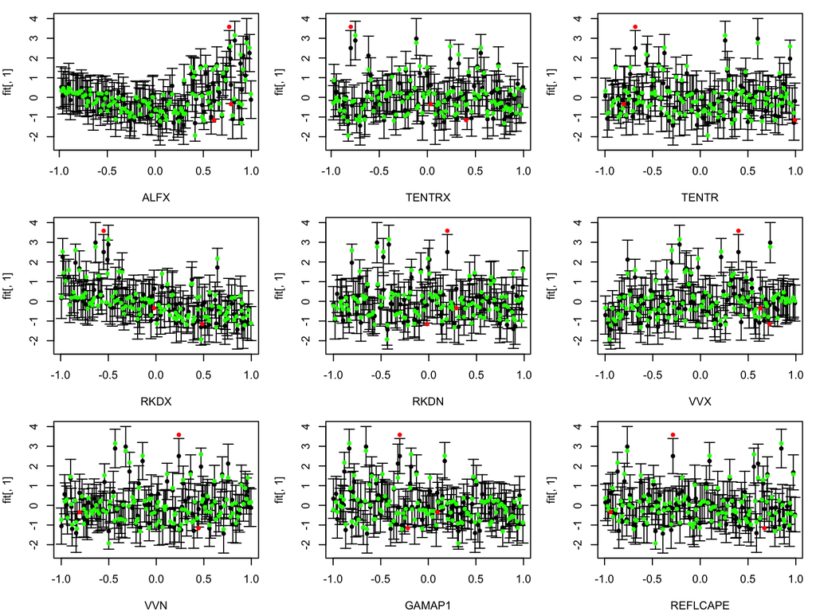

```r
clim.st.LOO <- LOO.plot(StanEmulator = myem.gp.cnrm,
                        ParamNames=colnames(myem.gp.cnrm$Design))
```

We also produce plots of standard errors against each input.

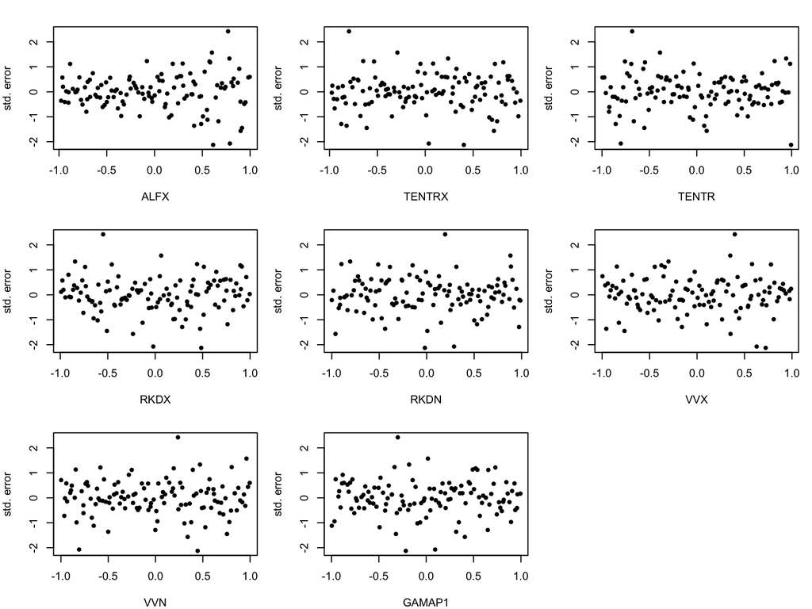

```r
std.err <- CalStError(clim.st.LOO, tData$SCMdata)
par(mfrow = c(3, 3), mar = c(4, 4, 2, 1))
for(i in 1:(length(cands)-1)) {
  plot(tData[, cands[i]], std.err, pch = 20, xlab = cands[i],
       ylab = 'std. error')
}
```

#### Mixture model

After obtaining the standard errors from a stationary fit, we proceed to modelling the mixture components. In `MIXTURE.design` function, we specify the form of function $g(\boldsymbol{x})$ in `formula`, which is linear with all input terms. We set `L=2`, since we assume that we have two input regions of distinct model behaviour.

```r
tData.mixture = as.data.frame(cbind(tData[, cands], std.err))
myem.cnrm.mixture <- MIXTURE.design(formula =std.err~
                              ALFX+TENTRX+TENTR+RKDX+RKDN+VVX+VVN+GAMAP1+REFLCAPE,
                              tData.mixture =tData.mixture, L = 2)
```

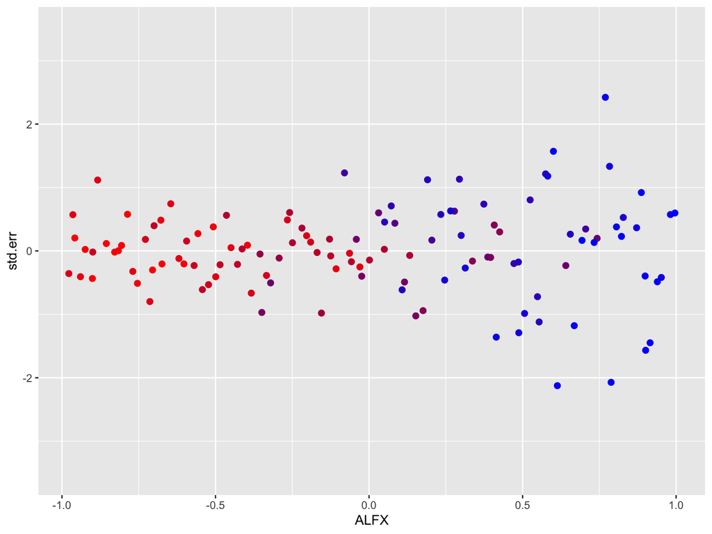

```r
mixture.cnrm <- data.frame(cbind(tData[, cands], std.err,
                                 myem.cnrm.mixture$MixtureMat))
names(mixture.cnrm) <- c(cands, 'std.err', 'red', 'blue')
p1 <- ggplot(mixture.cnrm, aes(x = ALFX, y = std.err, col = rgb(red = red, blue = blue, green = 0), ymin = -3.5, ymax=3.5)) +
  geom_point(size = 2) + scale_color_identity()
p1
```

#### Construct a nonstationary GP model.

We proceed to fit a nonstationary GP model. We use the same form of the linear function as we used for statinary GP model.

```r
  myem.gp.cnrm.nst <- EMULATE.gpstanNSt(meanResponse=myem.lm.cnrm, tData=tData,
                                        additionalVariables=NULL,
                                        FastVersion = TRUE, mixtureComp=
                                        myem.cnrm.mixture,
                                        sigmaPrior = TRUE)
```

#### Diagnostics for a nonstationary GP emulator.

Similar to a stationary GP emulator, we proceed to perform LOO diagnstics.

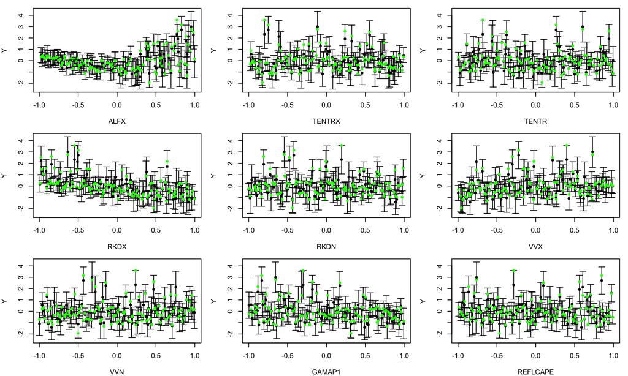

```r
LOOs.nst <- LOO.plot.NSt(StanEmulator = myem.gp.cnrm.nst,
                         ParamNames=colnames(myem.gp.cnrm.nst$Design))
```

#### Comparison

We compare the performance of stationary and nonstationary emulators on a validation set. The posterior mean and two standard deviation prediction intercals produced by emulators are in black. The green and red points are the model values, coloured ‘green’ if they lie within two standard deviation prediction intervals and ‘red’ if they lie outside.

```r
predict.st <- EMULATOR.gpstan(tData.valid, Emulator = myem.gp.cnrm, FastVersion = FALSE)
predict.nst <- EMULATOR.gpstanNSt(tData.valid, mixtureComp = myem.cnrm.mixture,
                                  Emulator = myem.gp.cnrm.nst, FastVersion = FALSE)
```

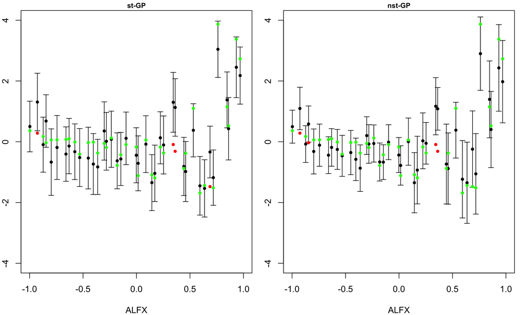

```r
predict.st.plot <- cbind(predict.st$Expectation,
                        predict.st$Expectation - 2*sqrt(predict.st$Variance),
                        predict.st$Expectation + 2*sqrt(predict.st$Variance))
predict.nst.plot <- cbind(predict.nst$Expectation,
                        predict.nst$Expectation - 2*sqrt(predict.nst$Variance),
                        predict.nst$Expectation + 2*sqrt(predict.nst$Variance))
par(mfrow = c(1, 2), mar = c(4, 2, 1, 1))
ValidPlot(predict.st.plot, tData.valid, tData.valid$SCMdata,
          axis = 1, heading =  "st-GP", xrange = c(-1, 1),
          ParamNames = cands,
            interval = c(-4, 4))
ValidPlot(predict.nst.plot, tData.valid, tData.valid$SCMdata,
          axis = 1, heading =  "nst-GP", xrange = c(-1, 1),
          ParamNames = cands,
            interval = c(-4, 4))
```